# Getting Started with Python

- 1. Packages
- 2. Control Flow
  - 2.1. if Statements
  - 2.2. Loops
    - 2.2.1. for loops
    - 2.2.2. Nested loops
    - 2.2.3. While loops
    - 2.2.4. break
- 3. Defining a Function
  - 3.1. functions with two arguments
- 4. Plots
  - 4.1. Pyplot
  - 4.2. subplot
  - 4.3. Three-dimensional plotting
- 5. Symbolic computations in Python
- 6. Data Structures
  - 6.1. Lists
    - 6.2. Using Lists as Queues
    - 6.3. List Comprehensions
- 7. Linear-algebra
  - 7.1. Matrix
    - 7.1.1. zeros
    - 7.1.2. Sparse matrices
  - 7.2. Dictionaries
  - 7.3. Manipulating data
    - 7.3.1. Importing Data from Github
    - 7.3.2. CSV File Reading and Writing
    - 7.3.4. DataFrame

In this notebook, we go through basic commands in python. Let's start with a simple command in Python.

```python
print('Hello World')
```

```
Hello World
```

Certainly, we can create more complex commands using **print()** that interested readers can find some of them [here](https://docs.python.org/3/tutorial/inputoutput.html).

# 1. Packages

Packages are an essential part of python that can make tasks easier for users. We can use the following syntax to install packages:

`!pip install packagename`

**Example**: Installing *numpy* package.

```python
!pip install numpy
```

Some useful package:

- **NumPy**: a package for computation and it includes a variety of tools from basic algebra to managing data.
- **Pandas**: a package that is used to create dataframe using imported data (from user or URL). This package is crucial for data analyzing.
- **SciPy**: a package for math, science, and engineering. It includes tools for optimization, linear algebra, integration, and many more.
- **Plotly**: It is used for visualization and creating two-dimensional and three-dimensional graphs.

One can import all contents of a package or import a particular part of it. We recommend importing packages using "as" feature (see blew for details). This allows importing many packages without being worried about any overlapping.

- `import abc`: importing the contents of the package or module *abc.
- `from abc import xyz`: importing only module or subpackage *xyz* from another package or module *abc*.
- `import abc as other_name`: to assign an imported package or module *abc* as *other_name*.

**Example**:

```python
# import numpy pcckage
import numpy
numpy.pi
```

```
3.141592653589793
```

```python
# from numpy pcckage import everything
from numpy import *
# * means import everything
pi
```

```
3.141592653589793
```

```python
# import abc as other_name
import numpy as np
np.pi
```

```
3.141592653589793
```

# 2. Control Flow

Control flow includes *Conditional statements*, *loops*, *branching*, ...

## 2.1. if Statements

We can use the following syntex to use *if*, *elif* and *else*.

```
if expression:
    statements
elif expression:
    statements
else:
    statements
end
```

**Example**: Checking wheter a given number $x$ is smaller than 10, equal 10 or greater than 10.

```python
# given number x
x = 10;
# Checking wheter a given number  x  is smaller than 10, equal 10 or greater than 10
if x<10:
    print('X is smaller than 10')
elif x==10:
    print('X is equal 10')
else:
    print('X is greater than 10')
```

```
X is equal 10
```

**Example**: Checking wheter given number $x$ and $y$ are smaller than 10, greater than 10 or none of above.

```python
# given nubmers x and y
x=11;y=9;
# Checking wheter given number  x and y are smaller than 10, greater than 10 or none of above.
if (x>10) & (y<10):
    print('x>10 & y<10')
elif (x<=10) & (y<10):
    print('x<=10 & y<10')
elif (x<=10) & (y>=10):
    print('x<=10 & y>=10')
else:
    print('None of above')
```

```
x>10 & y<10
```

## 2.2. Loops

Loops are used for iterating a process. Two popular loops are **for** and **while** loops.

### 2.2.1. for loops

*for* loop is used to repeat some statements for a specified number of times.

**Syntax**:

```
for index in values:
    statements
```

**Example**: Let's generate the following sequence using Python $$\{ 0, 1, 3, 6, 10, \ldots\}$$

```python
# the first 10 elements of the sequence
S=0;N=10;
for i in range(0,N):
    S+=i
    print("S_%d=%d" % (i,S))
```

```
S_0=0
S_1=1
S_2=3
S_3=6
S_4=10
S_5=15
S_6=21
S_7=28
S_8=36
S_9=45
```

To loop over a sequence in reverse, first specify the sequence in a forward direction and then call the [reversed()](https://docs.python.org/3/library/functions.html#reversed) function.

**Example**:

```python
N=5;
for i in reversed(range(0,N)):
    S=i
    print("S_%d=%d" % (i,S))
```

```
S_4=4
S_3=3
S_2=2
S_1=1
S_0=0
```

### 2.2.2. Nested loops

Implementing a loop inside another loop is called a nested loop. For example, we can

```
for loop: # Outer loop
    [doing something using the outer loop iteration]  # Optional
    for loop:   # Nested loop
        [doing something using nested loop iteration]
```

**Example**:

```python
for i in range(1,3):
    for j in range(1,4):
        print("%d+%d=%d" % (i,j,i+j))
```

```
1+1=2
1+2=3
1+3=4
2+1=3
2+2=4
2+3=5
```

**Note**: the the *second* loops runs first.

**Example**:

```python
num_list = [1, 2, 3]
alpha_list = ['a', 'b', 'c']

for N in num_list:
    for L in alpha_list:
        print("%s and %d" % (L,N))
```

```
a and 1
b and 1
c and 1
a and 2
b and 2
c and 2
a and 3
b and 3
c and 3
```

### 2.2.3. While loops

while loop is used to repeat some statements when condition is true

**Syntax**:

```
while expression:
    statements
```

**Example**:

```python
n = 100

s = 0
counter = 1
while counter <= n:
    s = s + counter
    counter += 1

print("Sum of 1 until %d: %d" % (n,s))
```

```
Sum of 1 until 100: 5050
```

We can generate the sequnece $\{ 0, 1, 3, 6, 10, \ldots\}$ using *while* loop as well.

```python
# the first 10 elements of the sequence
S=0;N=10;i=0;
while i<N:
    S+=i
    print("S_%d=%d" % (i,S))
    i+=1;
```

```
S_0=0
S_1=1
S_2=3
S_3=6
S_4=10
S_5=15
S_6=21
S_7=28
S_8=36
S_9=45
```

### 2.2.4. break

[source *python.org*]

The break statement, like in C, breaks out of the innermost enclosing for or while loop.

Loop statements may have an else clause; it is executed when the loop terminates through exhaustion of the list (with for) or when the condition becomes false (with while), but not when the loop is terminated by a break statement.

**Example**:

```python
for i in range(1,3):
    for j in range(1,4):
        if i+j==5:
            break
        else:
            print("%d+%d=%d" % (i,j,i+j))
```

```
1+1=2
1+2=3
1+3=4
2+1=3
2+2=4
```

**Example**:

```python
for i in range(1,3):
    for j in range(1,4):
        if i+j!=5:
            continue
        else:
            print("%d+%d=%d" % (i,j,i+j))
```

```
2+3=5
```

# 3. Defining a Function

**Syntax**

```
def functionname( parameters ):
   "function_docstring"
   function_suite
   return [expression]
```

**Example**:

```python
def Add3( x ):
    "This function adds 3 to x"
    print (x+3)
    return
```

```python
# x=1
Add3(1),
# x=2
Add3(2)
```

```
4
5
```

## 3.1. functions with two arguments

```python
def printinfo( name, age = 35 ):
  # print name
    print ("Name: ", name)
    # print age. If age is not defined, the default value is 35.
    print ("Age ", age)
    return
```

```python
printinfo( age = 50, name = "Henry" )
printinfo( name = "Henry" )
```

```
Name:  Henry
Age  50
Name:  Henry
Age  35
```

**Example**: the following function takes $x$ and $y$ and retruns $x^2$ and $y^2$.

```python
# the following function takes x and y and retruns x^2 and y^2.
def square(x,y):
    return x*x, y*y
```

```python
x2, y2 = square(3,10)
print(x2)
print(y2)
```

```
9
100
```

# 4. Plots

## 4.1. Pyplot

Pyplot from matplotlib (i.e. matplotlib.pyplot) provides a wide variety of function that can be compared with MATLAB plot functions.

**Example**: Let's plot a line using $\{(1,2),(2,4),(3,6),(4,8)\}$.

```python
import matplotlib.pyplot as plt
# define X
X=[1,2,3,4]
# define Y
Y=[2,4,6,8]
# ploting (X,Y)
plt.plot(X,Y)
plt.xlabel('x label')
plt.ylabel('y label')
plt.title('matplotlib plot using plot')
plt.show()
```

We also can use the following command to use *plot*

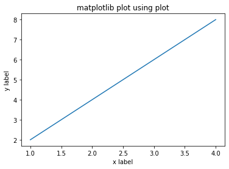

```python
from matplotlib.pyplot import *
X=[1,2,3,4];Y=[2,4,6,8];
plot(X,Y)
xlabel('x label'),ylabel('y label'),title('matplotlib plot using plot')
show()
```

We also can use `scatter` to plot discrete data. For Example,

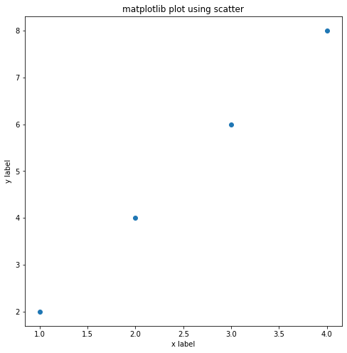

```python
import matplotlib.pyplot as plt
X=[1,2,3,4]
Y=[2,4,6,8]
# Figure size is Figure size 800x800 with 1 Axes
plt.figure(figsize = (8, 8))
plt.scatter(X,Y)
plt.xlabel('x label')
plt.ylabel('y label')
plt.title('matplotlib plot using scatter')
plt.show()
```

**Example**: Let's plot $\cos(\pi t)$ with $0\leq t \leq 5$

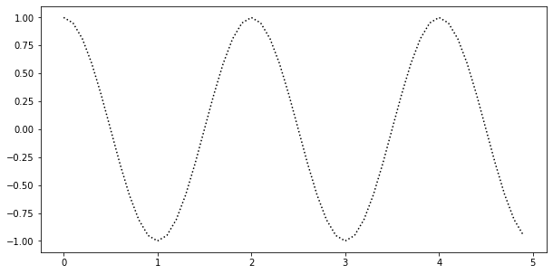

```python
import numpy as np
import matplotlib.pyplot as plt

## definining a function
def f(t):
    return np.cos(np.pi*t)
# discretizing [0,5] with dh=0.1
t = np.arange(0.0, 5.0, 0.1)
plt.figure(figsize = (10, 5))
plt.plot(t, f(t), 'k:')
```

- The hist() function automatically generates histograms and returns the bin counts or probabilities.

**Example**: The hist() function automatically generates histograms and returns the bin counts or probabilities.

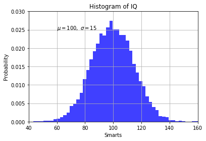

```python
import numpy as np
import matplotlib.pyplot as plt

# Fixing random state for reproducibility
np.random.seed(19680801)

mu, sigma = 100, 15
# random.randn(10000) creates a random array with the size of 10000
x = mu + sigma * np.random.randn(10000)

# the histogram of the data
n, bins, patches = plt.hist(x, 50, density=True, facecolor='b', alpha=0.75)


plt.xlabel('Smarts')
plt.ylabel('Probability')
plt.title('Histogram of IQ')

plt.text(60, .025, r'$\mu=100,\ \sigma=15$')
plt.axis([40, 160, 0, 0.03])
plt.grid(True)
plt.show()
```

## 4.2. subplot

Sometimes, it is more convenient to include more than one plot in a figure. Doins so, we can use **subplot**.

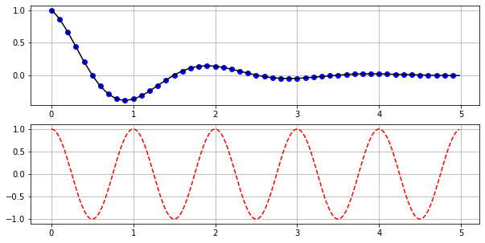

```python
import numpy as np
import matplotlib.pyplot as plt

# defining a function using lambda (simlar to @ in MATLAB)
f= lambda t : np.exp(-t)*np.cos(np.pi*t)
# discretizing
t1 = np.arange(0.0, 5.0, 0.1)
t2 = np.arange(0.0, 5.0, 0.02)

plt.subplots(figsize = (10, 5))
# The first subplot
plt.subplot(211)
plt.plot(t1, f(t1), 'bo', t2, f(t2), 'k')
plt.grid()
# The second subplot is plotting cos(2*np.pi*t2) but we do this using a different approach than the first one
plt.subplot(212)
plt.plot(t2, np.cos(2*np.pi*t2), 'r--')
plt.grid()
plt.show()
```

## 4.3. Three-dimensional plotting

We can use **mplot3d** from **mpl_toolkits** to generate 3D plots.

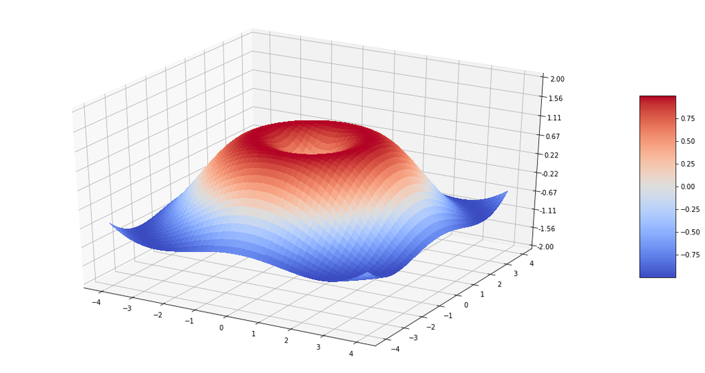

```python
from mpl_toolkits.mplot3d import Axes3D

import matplotlib.pyplot as plt
from matplotlib import cm
from matplotlib.ticker import LinearLocator, FormatStrFormatter
import numpy as np


fig = plt.figure(figsize = (20, 10))
ax = fig.gca(projection='3d')

# Make data.
X = np.arange(-4, 4, 0.02)
Y = np.arange(-4, 4, 0.02)
X, Y = np.meshgrid(X, Y)
R = np.sqrt(X**2 + Y**2)
Z = np.sin(R)

# Plot the surface.
surf = ax.plot_surface(X, Y, Z, cmap=cm.coolwarm,
                       linewidth=0, antialiased=False)

# Customize the z axis.
ax.set_zlim(-2.00, 2.00)
ax.zaxis.set_major_locator(LinearLocator(10))
ax.zaxis.set_major_formatter(FormatStrFormatter('%.02f'))

# Add a color bar which maps values to colors.
fig.colorbar(surf, shrink=0.5, aspect=5)

plt.show()
```

For more examples of plots, please check [here](https://matplotlib.org/tutorials/introductory/sample_plots.html).

# 5. Symbolic computations in Python

Let us define a symbolic expression and appy some useful functions on it [[source]](http://scipy-lectures.org/advanced/sympy.html).

| Function | Description |
| --- | --- |
| expand(expr) | expands the arithmetical expression expr. |
| simplify(expr) | transforms an expression into a simpler form. |
| factor(expr) | Factors a polynomial into irreducible polynomials. |
| diff(func, var, n) | Returns nth derivative of func . |
| integrate(func, var) | Evaluates Indefinite integral |
| integrate(func, (var, a, b)) | Evaluates Definite integral |
| limit(function, variable, point) | Evaluates Limit of symbolic expression. |
| series(expr, var, point, order) | Taylor series of an expression at a point. |
| solve | Equations and systems solver. |
| dsolve | solves differential equations. |

```python
from sympy import *
x, y = symbols('x y')
```

**Example**: (`expand`, `simplify` and `factor`)

```python
# expand
f = x**2 + 2*x*y
print("f^2=%s" % (f*f))
print("expand = %s" % expand(f*f))
print("simplify = %s" % simplify(f*f))
print("factor = %s" % factor(f*f))
```

```
f^2=(x**2 + 2*x*y)**2
expand = x**4 + 4*x**3*y + 4*x**2*y**2
simplify = x**2*(x + 2*y)**2
factor = x**2*(x + 2*y)**2
```

**Example**: (`diff`)

```python
print("f=%s" % (f))
print("f_x=%s" % diff(f, x))
print("f_y=%s" % diff(f, y))
print("f_xx=%s" % diff(f, x, 2))
print("f_yx=%s" % diff(diff(f, y),x))
```

```
f=x**2 + 2*x*y
f_x=2*x + 2*y
f_y=2*x
f_xx=2
f_yx=2
```

**Example**: (`integrate`)

```python
print("f=%s" % (f))
print("Indefinite integral (with respect to x) = %s" % integrate(f, x))
print("Indefinite integral (with respect to y) = %s" % integrate(f, y))

print("Definite integral (with respect to x on [2,3]) = %s" % integrate(f, (x,2,3)))
print("Definite integral (with respect to y on [2,3]) = %s" % integrate(f, (y,2,3)))
```

```
f=x**2 + 2*x*y
Indefinite integral (with respect to x) = x**3/3 + x**2*y
Indefinite integral (with respect to y) = x**2*y + x*y**2
Definite integral (with respect to x on [2,3]) = 5*y + 19/3
Definite integral (with respect to y on [2,3]) = x**2 + 5*x
```

**Example**: Let's compute

- (a) $\int_{-\infty}^\infty \sin{(x^2)}\,dx$
- (b) $\lim_{x\to 0}\frac{\sin{(x)}}{x}$
- (c) $\lim_{x\to -\infty}\exp(x)$

```python
## a
print("a=%s" % integrate(sin(x**2), (x, -oo, oo)))
## b
print("b=%s" % limit(sin(x)/x, x, 0))
## c
print("c=%s" % limit(exp(x), x, -oo))
```

```
a=sqrt(2)*sqrt(pi)/2
b=1
c=0
```

**Example**: Evaluate Taylor series of

- (a) $\sin(x)$ at $x=0$
- (a) $\cos(x)$ at $x=1$

```python
## a
print("(a) Taylor series of sin(x) at x=0 : %s " % series(sin(x), x))
## b
print("(b) Taylor series of cos(x) at x=0 : %s " % series(cos(x), x, 1, 3))
```

```
(a) Taylor series of sin(x) at x=0 : x - x**3/6 + x**5/120 + O(x**6)
(b) Taylor series of cos(x) at x=0 : cos(1) - (x - 1)*sin(1) - (x - 1)**2*cos(1)/2 + O((x - 1)**3, (x, 1))
```

**Example**: Let's solve the following equations

- (a) $x^3-1=0$ for $x$
- (b) $x+y=2$ for $y$

```python
solve(x**3 - 1, x)
```

```
[1, -1/2 - sqrt(3)*I/2, -1/2 + sqrt(3)*I/2]
```

```python
solve(x+y-2, y)
```

```
[2 - x]
```

**Example**: Let's solve the differential equation $y'' - y = e^x$.

```python
## displaying the soltuion in laTex format
init_printing(use_unicode=True)
#
from sympy import Function, dsolve, Eq, Derivative, sin, cos, symbols
from sympy.abc import x
y = Function('y')
dsolve(Derivative(y(x), x, x) -y(x)-exp(x), y(x))
```

$\displaystyle y{\left(x \right)} = C_{2} e^{- x} + \left(C_{1} + \frac{x}{2}\right) e^{x}$

We also can find the eigenvalues of a marix using Python

**Example**: Matrices

```python
Matrix([[1, 3], [3, 1]]).eigenvals()
```

$\displaystyle \left\{ -2 : 1, \ 4 : 1\right\}$

```python
x, y = symbols('x y')
Matrix([[0,x*x], [y*y,0]]).eigenvals()
```

$\displaystyle \left\{ - x y : 1, \ x y : 1\right\}$

Finally, we can print outputs in $\LaTeX$ format.

**Example**:

```python
latex(Integral(cos(x)**2, (x, 0, pi)))
```

```
'\\int\\limits_{0}^{\\pi} \\cos^{2}{\\left(x \\right)}\\, dx'
```

# 6. Data Structures

## 6.1. Lists

| Syntax | Description |
| --- | --- |
| list.append(x) | Add an item to the end of a list. |
| list.extend(iterable) | Extend a list by appending all the items from the iterable. |
| list.insert(i, x) | Insert an item at a given position of a list. |
| list.remove(x) | Remove the first item from a list whose value is equal to x. |
| list.pop([i]) | Remove the item at the given position in a list, and return it. |
| list.clear() | Remove all items from a list. |
| list.index(x[, start[, end]]) | Return zero-based index in a list of the first item whose value is equal to x. |
| list.count(x) | Return the number of times x appears in the list |
| list.sort(key=None, reverse=False) | Sort the items of the list in place. |
| list.reverse() | Reverse the elements of the list in place. |
| list.copy() | Return a shallow copy of the list. |

Here are all of the methods of list objects ([source](https://docs.python.org/3/tutorial/datastructures.html)):

**Example**:

```python
L=list(range(1,4))
print('L = %s' % L)
print('append: Add 5 to the end of a list.')
L.append(5)
print('L = %s' % L)
print('extend: Extend a list by appending [6,7].')
L.extend([6,7])
print('L = %s' % L)
print('insert: Insert 0 at position 0 of a list.')
L.insert(0, 0)
print('L = %s' % L)
print('insert: Insert 1.5 at position 2 of a list.')
L.insert(2, 1.5)
print('L = %s' % L)
print('remove: remove 2 from the list')
L.remove(2)
print('L = %s' % L)
print('remove: remove 1 from the list')
L.remove(1)
print('L = %s' % L)
```

```
L = [1, 2, 3]
append: Add 5 to the end of a list.
L = [1, 2, 3, 5]
extend: Extend a list by appending [6,7].
L = [1, 2, 3, 5, 6, 7]
insert: Insert 0 at position 0 of a list.
L = [0, 1, 2, 3, 5, 6, 7]
insert: Insert 1.5 at position 2 of a list.
L = [0, 1, 1.5, 2, 3, 5, 6, 7]
remove: remove 2 from the list
L = [0, 1, 1.5, 3, 5, 6, 7]
remove: remove 1 from the list
L = [0, 1.5, 3, 5, 6, 7]
```

**Example**:

```python
L=list(range(1,5))
print('L = %s' % L)
print('The first item of the list is %s' % L.pop(0))
print('The second item of the list is %s' % L.pop(0))
print('The last item of the list is %s' % L.pop())
```

```
L = [1, 2, 3, 4]
The first item of the list is 1
The second item of the list is 2
The last item of the list is 4
```

```python
L=list(range(1,5))
print('L = %s' % L)
print('Remove all items from a list:')
print('Using L.clear: %s' % L.clear())
```

```
L = [1, 2, 3, 4]
Remove all items from a list:
Using L.clear: None
```

**Example**:

```python
L=list(range(1,10))
print('L =  % s' % L)
print('the index of the first item whose value is equal to 5 is % s' % L.index(5))
```

```
L =  [1, 2, 3, 4, 5, 6, 7, 8, 9]
the index of the first item whose value is equal to 5 is 4
```

**Example**:

```python
L=[1, 1, 2, 5, 15, 3, 4]
print('L =  % s' % L)
print('the number of times 1 appears in the list = %s' % L.count(1))
L.sort(key=None, reverse=False)
print('Sort the items of the list in place : %s' % L)
L.reverse()
print('Reverse the elements of the list in place : %s' % L)
print('a copy of L = %s' % L.copy())
```

```
L =  [1, 1, 2, 5, 15, 3, 4]
the number of times 1 appears in the list = 2
Sort the items of the list in place : [1, 1, 2, 3, 4, 5, 15]
Reverse the elements of the list in place : [15, 5, 4, 3, 2, 1, 1]
a copy of L = [15, 5, 4, 3, 2, 1, 1]
```

**Example**:

```python
fruits = ['Apricots','Avocado','Watermelon','Strawberries','Orange', 'Apple', 'Banana', 'Kiwi', 'Apple', 'Strawberries']
## Count
print("The number of Strawberries = %i" % fruits.count('Strawberries'))
print("The number of Watermelon = %i" % fruits.count('Watermelon'))
```

```
The number of Strawberries = 2
The number of Watermelon = 1
```

```python
## Find
fruits.index('Watermelon', 1)  # Find next banana starting a position 1
```

$\displaystyle 2$

```python
# Reverse the elements of the list in place.
fruits.reverse()
fruits
```

```
['Strawberries',
 'Apple',
 'Kiwi',
 'Banana',
 'Apple',
 'Orange',
 'Strawberries',
 'Watermelon',
 'Avocado',
 'Apricots']
```

```python
# Add 'Pomegranate' to the end of the list
fruits.append('Pomegranate')
fruits
```

```
['Strawberries',
 'Apple',
 'Kiwi',
 'Banana',
 'Apple',
 'Orange',
 'Strawberries',
 'Watermelon',
 'Avocado',
 'Apricots',
 'Pomegranate']
```

```python
# Sort the items of the list in place
fruits.sort()
fruits
```

```
['Apple',
 'Apple',
 'Apricots',
 'Avocado',
 'Banana',
 'Kiwi',
 'Orange',
 'Pomegranate',
 'Strawberries',
 'Strawberries',
 'Watermelon']
```

```python
# pop here removes and returns the last item in the list.
fruits.pop()
```

```
'Watermelon'
```

```python
# Remove all items from the list.
fruits.clear()
fruits
```

$\displaystyle \left[ \right]$

## 6.2. Using Lists as Queues

We also can use a list as a queue, where the first element added is the first element retrieved (“first-in, first-out”); however, lists are not efficient for this purpose.

To implement a queue, use collections.deque which was designed to have fast appends and pops from both ends. For **Example**:

```python
from collections import deque
Premier_Leauge = deque(["Manchester City", "Liverpool FC", "Tottenham Hotspur"])
Premier_Leauge.append("Arsenal")
Premier_Leauge
```

```
deque(['Manchester City', 'Liverpool FC', 'Tottenham Hotspur', 'Arsenal'])
```

```python
Premier_Leauge.append("Manchester United")
Premier_Leauge.append("Chesea")
Premier_Leauge
```

```
deque(['Manchester City',
 'Liverpool FC',
 'Tottenham Hotspur',
 'Arsenal',
 'Manchester United',
 'Chesea'])
```

```python
Premier_Leauge.popleft()                 # The first to arrive now leaves
```

```
'Manchester City'
```

```python
Premier_Leauge                  # Remaining queue in order of arrival
```

```
deque(['Liverpool FC', 'Tottenham Hotspur', 'Arsenal', 'Manchester United', 'Chesea'])
```

## 6.3. List Comprehensions

For **Example**, assume we want to create a set $$S_n=\left\{\frac{1}{1+n^2} \right\}_{n>=0}.$$

```python
Sn = []; N=5;
for n in range(N):
    Sn.append(1/(1+n**2))
Sn
```

$\displaystyle \left[ 1.0, \ 0.5, \ 0.2, \ 0.1, \ 0.058823529411764705\right]$

We also can generate $S_n$ using either of the following commands

```python
Sn = list(map(lambda n: (1/(1+n**2)), range(N)))
Sn = [(1/(1+n**2)) for n in range(N)]
Sn
```

$\displaystyle \left[ 1.0, \ 0.5, \ 0.2, \ 0.1, \ 0.058823529411764705\right]$

**Example**: let's contruct the following set $$ S=\left\{\left(x,y\right)~|~\left(x,y\right)\in \mathbb{Z}_2\times\mathbb{Z}_2~ \&~ x\neq y\right\} $$

```python
[(x, y) for x in range(-1,1) for y in range(-1,1) if x!= y]
```

$\displaystyle \left[ \left( -1, \ 0\right), \ \left( 0, \ -1\right)\right]$

We could generate this set using nested loops as well

```python
Sn = []
for x in range(-1,1):
    for y in range(-1,1):
        if x != y:
            Sn.append((x, y))
Sn
```

$\displaystyle \left[ \left( -1, \ 0\right), \ \left( 0, \ -1\right)\right]$

# 7. Linear algebra

A $m$ by $n$ matrix in Python is basically a list of a list as a matrix having $m$ rows and $n$ columns. For **Example**:

```python
[[1, 2, 3],[4, 5, 6],[7, 8, 9]]
```

$\displaystyle \left[ \left[ 1, \ 2, \ 3\right], \ \left[ 4, \ 5, \ 6\right], \ \left[ 7, \ 8, \ 9\right]\right]$

## 7.1. Matrix

| Syntax | Description |
| --- | --- |
| mat(data[, dtype]) | Interpret the input as a matrix. |
| matrix(data[, dtype, copy]) |  |
| asmatrix(data[, dtype]) | Interpret the input as a matrix. |
| bmat(obj[, ldict, gdict]) | Build a matrix object from a string, nested sequence, or array. |
| empty(shape[, dtype, order]) | Return a new matrix of given shape and type, without initializing entries. |
| zeros(shape[, dtype, order]) | Return a matrix of given shape and type, filled with zeros. |
| ones(shape[, dtype, order]) | Matrix of ones. |
| eye(n[, M, k, dtype, order]) | Return a matrix with ones on the diagonal and zeros elsewhere. |
| identity(n[, dtype]) | Returns the square identity matrix of given size. |
| repmat(a, m, n) | Repeat a 0-D to 2-D array or matrix MxN times. |
| rand(*args) | Return a matrix of random values with given shape. |
| randn(*args) | Return a random matrix with data from the “standard normal” distribution. |

We can create a matrix using `numpy.matrix` as well. **Example**:

```python
# We can use
from numpy import *
matrix('1 2 3; 4 5 6; 7 8 9')
## or
import numpy as np
np.matrix('1 2 3; 4 5 6; 7 8 9')
```

```
matrix([[1, 2, 3],
        [4, 5, 6],
        [7, 8, 9]])
```

To access an entry of this matrix we can

```python
import numpy as np
M=np.matrix('1 2 3; 4 5 6; 7 8 9')
print('M_2,2 = %d' % M[1,1])
print('M_1,1 = %d' % M[0,0])
```

```
M_2,2 = 5
M_1,1 = 1
```

**Note**: Unlike *MATLAB*, here indeces start from **0**

### 7.1.1. zeros

**Syntax**: `numpy.zeros(shape, dtype=float, order='C')`

**Notes**:

- The desired data-type for the array, e.g., numpy.int8. Default is numpy.float64.
- order : {‘C’, ‘F’}, optional. Whether to store multidimensional data in C- or Fortran-contiguous (row- or column-wise) order in memory.

**Example**: We also create matrices using nested loops.

```python
import numpy as np
M=3;N=3;
A=np.zeros((M,N), dtype=np.int)
for ix in range(M):
    for iz in range(N):
        A[ix,iz]=ix+iz
print("A =", A)
```

```
A = [[0 1 2]
 [1 2 3]
 [2 3 4]]
```

The size of this matrix can be also found as

```python
np.shape(A) # This gives the length of the array
```

$\displaystyle \left( 3, \ 3\right)$

**Example**: Let's transpose matrix A.

```python
[[ row[i] for row in A] for i in range(M)]
```

```
[[0, 1, 2], [1, 2, 3], [2, 3, 4]]
```

We can generate a matrix using zip function as well. For **Example**:

```python
A=zip(range(M),range(M))
A=list(A)
print("A =", A)
```

```
A = [(0, 0), (1, 1), (2, 2)]
```

We can delete some elements of a list using del function. For **Example**:

```python
A=list(range(10))
print("A =", A)
```

```
A = [0, 1, 2, 3, 4, 5, 6, 7, 8, 9]
```

```python
del(A[2]) # deleting the third element
print("A =", A)
```

```
A = [0, 1, 3, 4, 5, 6, 7, 8, 9]
```

```python
del(A[6:9]) # deleting the last 3 elements
print("A =", A)
```

```
A = [0, 1, 3, 4, 5, 6]
```

We can also use [numpy.matrix](https://docs.scipy.org/doc/numpy-1.13.0/reference/generated/numpy.matrix.html) to create matrices. For **Example**:

```python
A = np.matrix('1 2; 3 4')
print("A =", A)
```

```
A = [[1 2]
 [3 4]]
```

### 7.1.2. Sparse matrices

We can use **scipy** to define sparse matrices. For **Example**:

```python
# import sparse module from SciPy package
from scipy import sparse
# import uniform module to create random numbers
from scipy.stats import uniform
# import NumPy
import numpy as np

A=[[1, 0, 0, 0],[2, 2, 0, 0],[1, 0, 0, 1]]
SparseA=sparse.csr_matrix(A)
print(SparseA)
```

```
  (0, 0)	1
  (1, 0)	2
  (1, 1)	2
  (2, 0)	1
  (2, 3)	1
```

## 7.2. Dictionaries

A pair of braces creates an empty dictionary: {}. Placing a comma-separated list of key:value pairs within the braces adds initial key:value pairs to the dictionary; this is also the way dictionaries are written on output. We are going to explain this using an **Example**:

```python
PL_Champions={"Manchester United" : '2012–13',
              "Leicester City" : '2015–16',
              "Chelsea" : '2016–17',
              "Manchester City" : '2017–18'}
print("Premier League Champions = ", PL_Champions)
```

```
Premier League Champions =  {'Manchester United': '2012–13', 'Leicester City': '2015–16', 'Chelsea': '2016–17', 'Manchester City': '2017–18'}
```

```python
# Add a value to the dictionary
PL_Champions["Arsenal"]='2003–04'
print("Premier League Champions = ", PL_Champions)
```

```
Premier League Champions =  {'Manchester United': '2012–13', 'Leicester City': '2015–16', 'Chelsea': '2016–17', 'Manchester City': '2017–18', 'Arsenal': '2003–04'}
```

```python
# Remove a key and it's value
del PL_Champions["Arsenal"]
print("Premier League Champions = ", PL_Champions)
```

```
Premier League Champions =  {'Manchester United': '2012–13', 'Leicester City': '2015–16', 'Chelsea': '2016–17', 'Manchester City': '2017–18'}
```

```python
# The len() function gives the number of pairs in the dictionary.
print("The Length = ", len(PL_Champions) )
```

```
The Length =  4
```

```python
# Test the dictionary
'Liverpool' in PL_Champions
```

```
False
```

```python
# Test the dictionary
'Leicester City' in PL_Champions
```

```
True
```

```python
# Print all key and values
print("-" * 100)
print('Premier League Champions')
print("-" * 100)
for k, v in PL_Champions.items():
    print(k, v)
```

```
----------------------------------------------------------------------------------------------------
Premier League Champions
----------------------------------------------------------------------------------------------------
Manchester United 2012–13
Leicester City 2015–16
Chelsea 2016–17
Manchester City 2017–18
```

```python
# Get only the keys from the dictionary
print(PL_Champions.keys())
```

```
dict_keys(['Manchester United', 'Leicester City', 'Chelsea', 'Manchester City'])
```

```python
# When looping through a sequence, the position index and corresponding value can be retrieved at the same time using
# the enumerate() function.
for i, v in enumerate(PL_Champions.items()):
    print(i, v)
```

```
0 ('Manchester United', '2012–13')
1 ('Leicester City', '2015–16')
2 ('Chelsea', '2016–17')
3 ('Manchester City', '2017–18')
```

```python
# To loop over two or more sequences at the same time, the entries can be paired with the zip() function.
Year=['2012–13', '2015–16', '2016–17', '2017–18']
Champ=['Manchester United', 'Leicester City', 'Chelsea', 'Manchester City']

for Y, C in zip(Year, Champ):
    print('The Champtions of the Premier League in {0}?  It is {1}.'.format(Y, C))
```

```
The Champtions of the Premier League in 2012–13?  It is Manchester United.
The Champtions of the Premier League in 2015–16?  It is Leicester City.
The Champtions of the Premier League in 2016–17?  It is Chelsea.
The Champtions of the Premier League in 2017–18?  It is Manchester City.
```

## 7.3. Manipulating data

### 7.3.1. Importing Data from Github

```python
import pandas as pd
data = pd.read_csv("https://raw.githubusercontent.com/HatefDastour/Python/master/Data/PL18_19.csv")
```

```python
print('Data Size = ',data.shape)
print('columns heading = ',data.Won)
print('The first 3 rows of Won column:')
print(data['Points'][0:3])
```

```
Data Size =  (20, 9)
columns heading =  0     32
1     30
2     21
3     23
4     21
5     19
6     16
7     15
8     15
9     15
10    14
11    14
12    12
13    13
14    11
15     9
16     9
17    10
18     7
19     3
Name: Won, dtype: int64
The first 3 rows of Won column:
0    98
1    97
2    72
Name: Points, dtype: int64
```

To read only one column, we can use *Use dataframe.column_title*

```python
data.Club
```

```
0               Manchester City
1                     Liverpool
2     Previous Position Chelsea
3             Tottenham Hotspur
4                       Arsenal
5             Manchester United
6       Wolverhampton Wanderers
7                       Everton
8                Leicester City
9               West Ham United
10                      Watford
11               Crystal Palace
12             Newcastle United
13                  Bournemouth
14                      Burnley
15                  Southampton
16     Brighton and Hove Albion
17                 Cardiff City
18                       Fulham
19            Huddersfield Town
Name: Club, dtype: object
```

### 7.3.2. CSV File Reading and Writing

We are going to create a CSV file, `names.csv` and fill it with some names. For more detials please see https://docs.python.org/3.4/library/csv.html

```python
import csv

with open('names.csv', 'w') as csvfile:
    fieldnames = ['first_name', 'last_name']
    writer = csv.DictWriter(csvfile, fieldnames=fieldnames)

    writer.writeheader()
    writer.writerow({'first_name': 'Jason', 'last_name': 'Bourne'})
    writer.writerow({'first_name': 'James', 'last_name': 'Bond'})
    writer.writerow({'first_name': 'Bruce', 'last_name': 'Wayne'})
```

```python
import csv
with open('names.csv', newline='') as f:
    reader = csv.reader(f)
    for row in reader:
        print(row)
```

```
['first_name', 'last_name']
[]
['Jason', 'Bourne']
[]
['James', 'Bond']
[]
['Bruce', 'Wayne']
[]
```

### 7.3.4. DataFrame

A pandas DataFrame can be created using the following constructor −

`pandas.DataFrame( data, index, columns, dtype, copy)`

```python
import numpy as np
import pandas as pd
# MLS 2018 Top Scorers
data = {'Player': ['Josef Martinez', 'Zlatan Ibrahimovic', 'Bradley Wright-Phillips', 'Mauro Manotas'],
        'Team': ['Atlanta','LA Galaxy','NY Red Bulls','Houston'],
        'Goals': [31, 22, 20, 19]}
df = pd.DataFrame(data, index = ['1','2','3','4'])
df
```

|  | Player | Team | Goals |
| --- | --- | --- | --- |
| 1 | Josef Martinez | Atlanta | 31 |
| 2 | Zlatan Ibrahimovic | LA Galaxy | 22 |
| 3 | Bradley Wright-Phillips | NY Red Bulls | 20 |
| 4 | Mauro Manotas | Houston | 19 |

For more information please check this [link](https://pandas.pydata.org/pandas-docs/stable/reference/api/pandas.DataFrame.html).